# Neuro analyses

```r
library(dplyr)
library(tidyr)
library(readr)
library(ggplot2)
library(readxl)
library(httr)
library(rcartocolor)
library(stringr)
library(forcats)
library(purrr)
library(stringi)
library(DT)

theme_set(theme_bw() + theme(legend.title = element_blank()))
source('utils.R')
```

## Download data

```r
github_link <- 'https://raw.githubusercontent.com/covidclinical/Phase1.1AggregateDataPerSite/master/'
demo_link <- paste0(github_link, 'Demographics_persite_fakeID.csv')
diag_link <- paste0(github_link, 'Diagnoses_persite_fakeID.csv')

temp_file_1 <- temp_file_2 <- tempfile(fileext = ".csv")
req <- GET(demo_link,
          # authenticate using GITHUB_PAT
           authenticate(Sys.getenv("GITHUB_PAT"), ""),
          # write result to disk
           write_disk(path = temp_file_1))
demo_all <- read_csv(temp_file_1)
unlink(temp_file_1)

req <- GET(diag_link,
           authenticate(Sys.getenv("GITHUB_PAT"), ""),
           write_disk(path = temp_file_2))
diag_all <- read_csv(temp_file_2)
unlink(temp_file_2)
```

Notes: - `num_patients_ever_severe_icd1`: number of patients having the icd code and ever being severe - `num_patients_never_severe_icd1`: number of patients having the icd code and never being severe - `num_patients_ever_severe_icd0`: number of patients not having the icd code and ever being severe - `num_patients_never_severe_icd0`: number of patients not having the icd code and never being severe

## Read in local files

```r
icds_of_interest <- read_excel('data/2020-09-10_neuro-icd10.xlsx') %>%
  rename('icd' = `ICD-10`)
```

Notes:

“-99” indicate masked small numbers (for obfuscation) and “-999” indicate missing, unknown, not applicable, etc.

# Descriptive statistics

## Mold data frames

```r
# diag_ana <- diag_all %>%
#   mutate(all_nas = is.na(num_patients_ever_severe_icd0) &
#            is.na(num_patients_ever_severe_icd1) &
#            is.na(num_patients_never_severe_icd0)&
#            is.na(num_patients_never_severe_icd1)) %>%
#   filter(!all_nas) %>%
#   select(-all_nas) %>%
#   mutate(
#     num_patients_icd = num_patients_ever_severe_icd1 + num_patients_never_severe_icd1,
#     icd = gsub('icd:', '', icd),
#     time = recode(time,
#                   before_admission = 'Before admission',
#                   since_admission = 'After admission')) %>%
#   # left_join(site_to_country, by = 'siteid') %>%
#   right_join(icds_of_interest, by = 'icd') %>%
#   distinct() %>%
#   mutate(full_icd = paste0(`ICD-10 Description`, ' (', icd, ')')) %>%
#   {.}
# site_pats <- demo_ana %>%
#   group_by(siteid) %>%
#   summarise(num_patients_all = sum(num_patients_all), .groups = 'drop')
```

```r
demo_ana <- demo_all %>%
  filter(race == 'all', age_group == 'all', sex == 'all') %>%
  # left_join(site_to_country, by = 'siteid') %>%
  select(- c(sex, age_group, race)) %>%
  bind_rows(# Compute patients_all for SITE734 manually
    demo_all %>%
      filter(siteid == 'SITE734', race == 'all', age_group == 'all') %>%
      group_by(siteid) %>%
      summarise(across(c(num_patients_all, num_patients_ever_severe), .fns = sum),
                .groups = 'drop')
  ) %>%
  mutate(num_patients_never_severe = num_patients_all - num_patients_ever_severe)


split_patient_type <- function(x) {
  temp <- strsplit(sub('(^[^_]+_[^_]+)_(.*)$', '\\1 \\2', stri_reverse(x)), ' ')
  map(temp, stri_reverse)
}

diag_ana <- diag_all %>%
  mutate(
    num_patients_never_severe_before_admission = num_patients_all_before_admission - num_patients_ever_severe_before_admission,
    num_patients_never_severe_since_admission = num_patients_all_since_admission - num_patients_ever_severe_since_admission,
  ) %>%
  pivot_longer(cols = starts_with('num'), names_to = 'patient_type', values_to = 'count') %>%
  bind_cols(
    split_patient_type(.[['patient_type']]) %>%
      do.call(rbind, .) %>%
      as.data.frame() %>%
      `colnames<-`(c('time', 'severe'))
  ) %>%
  mutate(severe = recode(severe,
                         num_patients_all = 'num_patients_icd',
                         num_patients_ever_severe= 'num_patients_ever_severe_icd1',
                         num_patients_never_severe= 'num_patients_never_severe_icd1'),
         time = recode(time,
                       before_admission = 'Before admission',
                       since_admission = 'After admission')) %>%
  rename('icd' = icd_code_3chars) %>%
  filter(icd_version == 10) %>%
  select(- c(icd_version, patient_type)) %>%
  pivot_wider(names_from = severe, values_from = count, values_fill = 0) %>%
  right_join(icds_of_interest, by = 'icd') %>%
  distinct() %>%
  left_join(demo_ana, by = 'siteid') %>%
  mutate(full_icd = paste0(`ICD-10 Description`, ' (', icd, ')'),
         num_patients_never_severe_icd0 = num_patients_never_severe - num_patients_never_severe_icd1,
         num_patients_ever_severe_icd0 = num_patients_ever_severe - num_patients_ever_severe_icd1,
  ) %>%
  drop_na(num_patients_icd) %>%
  {.}
```

Only 40 sites with icd-10 code. 5 sites have icd-9.

Check NAs:

```r
na_diag <- diag_ana %>%
  select(siteid, icd, contains('num')) %>%
  filter(rowSums(is.na(.)) > 0)
```

Calculate percentages:

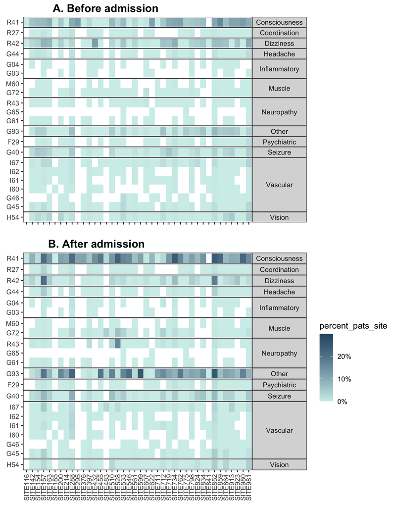

```r
code_prevalence <- diag_ana %>%
  group_by(siteid, time, icd, `Neurological Disease Category`, full_icd) %>%
  # summarise(pats_time_icd_site = sum(num_patients_icd), .groups = 'drop') %>%
  # left_join(demo_ana, by = 'siteid') %>%
  mutate(percent_pats_site = num_patients_icd/num_patients_all,
         siteid = as.factor(siteid))

before_code_prev <- code_prevalence %>%
  filter(time == 'Before admission',
         siteid != 'SITE309') %>%
  ggplot(aes(y = icd, x = siteid, fill = percent_pats_site)) +
  geom_tile() +
  labs(y = NULL, x = NULL) +
  #f6d2a9,#f5b78e,#f19c7c,#ea8171,#dd686c,#ca5268,#b13f64
  scale_fill_gradient(
    # low = '#f6d2a9', high = '#b13f64',
    low = '#d1eeea', high = '#2a5674',
    labels = scales::percent_format(accuracy = 1),
    limits = c(0, 0.3),
    guide = guide_legend(override.aes = list(fill = "white"))) +
  scale_x_discrete(drop = F) +
  facet_grid(rows = vars(`Neurological Disease Category`), space = 'free', scale = 'free') +
  heat_theme_top() +
  NULL

after_code_prev <- code_prevalence %>%
  filter(time == 'After admission',
         siteid != 'SITE309') %>%
  ggplot(aes(y = icd, x = siteid, fill = percent_pats_site)) +
  geom_tile() +
  labs(y = NULL, x = NULL) +
  scale_x_discrete(drop = F) +
  #d1eeea,#a8dbd9,#85c4c9,#68abb8,#4f90a6,#3b738f,#2a5674
  scale_fill_gradient(low = '#d1eeea', high = '#2a5674',
                      labels = scales::percent_format(accuracy = 1),
                      limits = c(0, 0.3)) +
  facet_grid(rows = vars(`Neurological Disease Category`), space = 'free', scale = 'free') +
  heat_theme_bottom() +
  NULL

heats <- cowplot::plot_grid(before_code_prev, after_code_prev, ncol = 1,
                            rel_heights = c(1, 1.15),
                   labels = c('A. Before admission', 'B. After admission'))
heats
```

```r
ggsave('figs/icd_heatmap.png', heats, height = 10, width = 7)
```

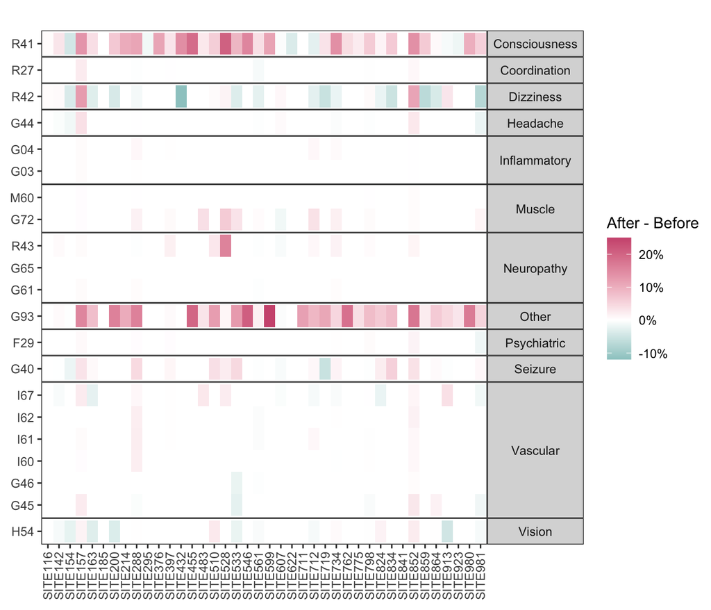

```r
diff_code <- code_prevalence %>%
  filter(siteid != 'SITE309') %>%
  pivot_wider(names_from = time, values_from = percent_pats_site, id_cols = c(siteid, icd, `Neurological Disease Category`), values_fill = 0) %>%
  mutate(percent_diff = `After admission` - `Before admission`)

diff_heat <- diff_code %>%
  ggplot(aes(y = icd, x = siteid, fill = percent_diff)) +
  geom_tile() +
  labs(y = NULL, x = NULL, fill = 'After - Before') +
  scale_x_discrete(drop = F) +
  #009392,#39b185,#9ccb86,#e9e29c,#eeb479,#e88471,#cf597e
  scale_fill_gradient2(
    low = '#009392',
    high = '#cf597e',
    labels = scales::percent_format(accuracy = 1)) +
  facet_grid(rows = vars(`Neurological Disease Category`), space = 'free', scale = 'free') +
  heat_theme_bottom() +
  NULL
diff_heat
```

```r
ggsave('figs/icd_diff_heatmap.png', diff_heat, height = 5.5, width = 7)
```

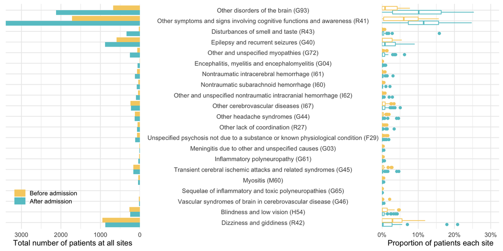

```r
icd_time <- diag_ana %>%
  filter(siteid != 'SITE309') %>%
  group_by(full_icd, time) %>%
  summarise(pats_icd_time = sum(num_patients_icd, na.rm = T), .groups = 'drop')
# sorted_icds <- icd_time %>%
#   filter(time == 'After admission') %>%
#   arrange(pats_icd_time) %>%
#   pull(full_icd)
sorted_icds <- code_prevalence %>%
  ungroup() %>%
  select(time, percent_pats_site, full_icd, siteid) %>%
  pivot_wider(names_from = time, values_from = percent_pats_site, values_fill = 0) %>%
  group_by(full_icd) %>%
  summarise(after = mean(`After admission`, na.rm = T),
         before = mean(`Before admission`, na.rm = T),
         diff_prev = after - before,
         .groups = 'drop') %>%
  arrange(diff_prev) %>%
  pull(full_icd)

total_icd <- icd_time %>%
  ggplot(aes(x = pats_icd_time, y = fct_relevel(full_icd, sorted_icds), fill = time)) +
  scale_fill_carto_d(palette = 4, guide = guide_legend(reverse = TRUE)) +
  geom_col(position = 'dodge') +
  theme_minimal() +
  scale_x_reverse(expand = expansion(add = c(0,0))) +
  scale_y_discrete(labels = NULL) +
  theme(legend.position = c(0.3, 0.15),
        legend.title = element_blank(),
        legend.key.height = unit(4, 'mm')) +
  labs(x = 'Total number of patients at all sites', y = NULL)

percent_icd <- code_prevalence %>%
  filter(siteid != 'SITE309') %>%
  ggplot(aes(x = percent_pats_site,
             y = fct_relevel(full_icd, sorted_icds),
             color = time)) +
  scale_color_carto_d(palette = 4, guide = NULL) +
  # scale_color_manual(values = c('#2a5674', '#b13f64')) +
  geom_boxplot(fill = 'white') +
  theme_minimal() +
  theme(legend.position = c(0.75, 0.1),
        legend.title = element_blank(),
        axis.text.y = element_text(hjust = 0.5)) +
  scale_x_continuous(expand = expansion(add = c(0, 0.07)),
                     labels = scales::percent_format(accuracy = 1)) +
  labs(x = 'Proportion of patients each site', y = NULL)

icd_prevalence_plots <- cowplot::plot_grid(total_icd, percent_icd, ncol = 2,
                   rel_widths = c(1, 2.5))
icd_prevalence_plots
```

```r
ggsave('figs/icd_prevalence.png', icd_prevalence_plots, height = 5, width = 10)
```

# Severity analysis

What ICD code has the most number severe patients? Sites with more severe patients?

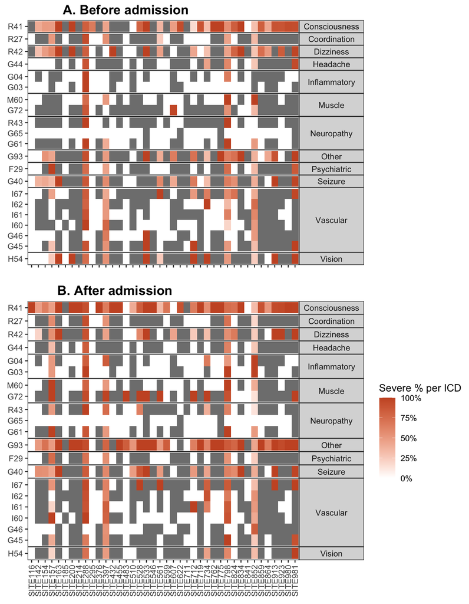

```r
severe_code <- diag_ana %>%
  filter(siteid != 'SITE309') %>%
  mutate(percent_severe_site = num_patients_ever_severe_icd1/num_patients_icd,
         siteid = as.factor(siteid))

severe_bef_heat <- severe_code %>%
  filter(time == 'Before admission') %>%
  ggplot(aes(y = icd, x = siteid, fill = percent_severe_site)) +
  geom_tile() +
  labs(y = NULL, x = NULL, fill = 'Severe % per ICD') +
  #3d5941,#778868,#b5b991,#f6edbd,#edbb8a,#de8a5a,#ca562c
  scale_fill_gradient(
    # low = '#f6d2a9', high = '#b13f64',
    low = 'white', high = '#ca562c',
    guide = guide_legend(override.aes = list(fill = "white")),
    ) +
  scale_x_discrete(drop = F) +
  facet_grid(rows = vars(`Neurological Disease Category`), space = 'free', scale = 'free') +
  heat_theme_top() +
  NULL

severe_aft_heat <- severe_code %>%
  filter(time == 'After admission') %>%
  ggplot(aes(y = icd, x = siteid, fill = percent_severe_site)) +
  geom_tile() +
  labs(y = NULL, x = NULL, fill = 'Severe % per ICD') +
  scale_x_discrete(drop = F) +
  #3d5941,#778868,#b5b991,#f6edbd,#edbb8a,#de8a5a,#ca562c
  scale_fill_gradient(
    low = 'white', high = '#ca562c',
    labels = scales::percent_format(accuracy = 1)) +
  facet_grid(rows = vars(`Neurological Disease Category`), space = 'free', scale = 'free') +
  heat_theme_bottom() +
  NULL

severe_heats <- cowplot::plot_grid(severe_bef_heat, severe_aft_heat, ncol = 1,
                            rel_heights = c(1, 1.15),
                   labels = c('A. Before admission', 'B. After admission'))
severe_heats
```

```r
ggsave('figs/icd_severe_heatmap.png', severe_heats, height = 10, width = 7)
```

# Severity enrichment analysis

## Null hypothesis:

For each ICD code, the proportion of severe patients who were diagnosed with that ICD code is similar to the proportion of never-severe patients who were diagnosed with that same ICD code.

**Is “enrichment” the right word to use here?**

For the sake of simplicity in this notebook, we’re going to denote patients whose symptoms have been categorized as severe (based on respiratory status +/- requiring ICU) at least once as *severe patients*, and patients whose symptoms have NEVER been categorized as severe as *non-severe patients*.

For each ICD code, we computed the expected number of *severe patients* by multiplying the proportion of *non-severe patients* who were diagnosed with that code with the total number of *severe patients*. We performed an enrichment analysis to examine the difference of *severe patients* proportions across ICD codes. We calculated each ICD code’s enrichment by dividing the observed proportion of honorees by the expected proportion of honorees and reported a value of log2 enrichment (LOE) and its 95% confidence intervals. The 95% confidence interval of the LOE was estimated using the Poisson model method [@isbn:9780849394447].

```r
contingency_df <- diag_ana %>%
  # filter(time == 'Before admission') %>%
  group_by(full_icd, time) %>%
  summarise(across(contains('severe'), .fns = sum, na.rm = T), .groups = 'drop') %>%
  mutate(Observed = num_patients_ever_severe_icd1,
         num_non_severe = num_patients_never_severe_icd1 + num_patients_never_severe_icd0,
         num_severe = num_patients_ever_severe_icd1 + num_patients_ever_severe_icd0,
         Expected = num_patients_never_severe_icd1/num_non_severe*num_severe,
         over_sev = Observed - Expected)

nested_obs_exp <- contingency_df %>%
  select(full_icd,
         time,
         num_patients_never_severe_icd0,
         num_patients_never_severe_icd1,
         num_patients_ever_severe_icd0,
         num_patients_ever_severe_icd1) %>%
  group_by(full_icd, time) %>%
  nest()

fish_obs_exp <- nested_obs_exp %>%
  mutate(fish = map(data, my_fish)) %>%
  dplyr::select(-data) %>%
  unnest(cols = c(fish)) %>%
  mutate(upper = ifelse(is.na(upper), Inf, upper))
```

```
## Warning in chisq.test(xx, correct = correction): Chi-squared approximation may
## be incorrect
```

```
## Warning: Problem with `mutate()` input `fish`.
## ℹ Chi-squared approximation may be incorrect
## ℹ Input `fish` is `map(data, my_fish)`.
## ℹ The error occurred in group 36: full_icd = "Sequelae of inflammatory and toxic polyneuropathies (G65)", time = "Before admission".
```

```
## Warning in chisq.test(xx, correct = correction): Chi-squared approximation may
## be incorrect
```

```r
fish_obs_exp$`P value (Holm)` <-  p.adjust(fish_obs_exp$p_value, 'holm')
fish_obs_exp$`P value (FDR)` <- p.adjust(fish_obs_exp$p_value, 'BH')
```

While the Warning messages mentioned Chi-squared, the p-values were actually calculated using Fisher’s Exact test (see more in `epitools::tab2by2.test()`).

Note: small number of observations for ICD-10 code G04, G03, G65:

```r
contingency_df %>%
  filter(grepl('G04|G03|G65', full_icd)) %>%
  datatable()
```

|  | full_icd | time | num_patients_ever_severe_icd1 | num_patients_never_severe_icd1 | num_patients_ever_severe | num_patients_never_severe | num_patients_never_severe_icd0 | num_patients_ever_severe_icd0 | Observed | num_non_severe | num_severe | Expected | over_sev |
| --- | --- | --- | --- | --- | --- | --- | --- | --- | --- | --- | --- | --- | --- |
| 1 | Encephalitis, myelitis and encephalomyelitis (G04) | After admission | 42 | 15 | 14053 | 12066 | 12051 | 14011 | 42 | 12066 | 14053 | 17.4701640974639 | 24.5298359025361 |
| 2 | Encephalitis, myelitis and encephalomyelitis (G04) | Before admission | 3 | 5 | 14053 | 12066 | 12061 | 14050 | 3 | 12066 | 14053 | 5.82338803248798 | -2.82338803248798 |
| 3 | Meningitis due to other and unspecified causes (G03) | After admission | 10 | 5 | 12918 | 10359 | 10354 | 12908 | 10 | 10359 | 12918 | 6.23515783376774 | 3.76484216623226 |
| 4 | Meningitis due to other and unspecified causes (G03) | Before admission | 4 | 6 | 11851 | 8244 | 8238 | 11847 | 4 | 8244 | 11851 | 8.62518195050946 | -4.62518195050946 |
| 5 | Sequelae of inflammatory and toxic polyneuropathies (G65) | After admission | 0 | 1 | 1971 | 837 | 836 | 1971 | 0 | 837 | 1971 | 2.35483870967742 | -2.35483870967742 |
| 6 | Sequelae of inflammatory and toxic polyneuropathies (G65) | Before admission | 0 | 1 | 1971 | 837 | 836 | 1971 | 0 | 837 | 1971 | 2.35483870967742 | -2.35483870967742 |

The full table with all ICD codes and their corresponding enrichment can be browsed interactively below:

```r
library(DT)
fish_tab <- fish_obs_exp %>%
  mutate(ci = paste0('(', round(log2(lower), 1), ', ',
                     round(log2(upper), 1), ')'),
         lestimate = log2(estimate)) %>%
  left_join(contingency_df, by = c('full_icd', 'time')) %>%
  select(full_icd, time, Observed, Expected, over_sev,
         estimate, lestimate, ci, p_value,
         `P value (Holm)`, `P value (FDR)`) %>%
  rename('ICD' = 'full_icd',
         'Observed - Expected' = 'over_sev',
         'Enrichment' = 'estimate',
         'Log2(enrichment)' = 'lestimate',
         '95% Confidence interval' = 'ci',
         'P value (raw)' = 'p_value')

fish_tab %>%
  datatable(rownames = FALSE) %>%
  formatRound(c('Observed', 'Expected', 'Observed - Expected',
                'Enrichment', 'Log2(enrichment)'), 1) %>%
  formatSignif(c('P value (raw)', 'P value (Holm)', 'P value (FDR)'), 3) %>%
  {.}
```

| ICD | time | Observed | Expected | Observed - Expected | Enrichment | Log2(enrichment) | 95% Confidence interval | P value (raw) | P value (Holm) | P value (FDR) |
| --- | --- | --- | --- | --- | --- | --- | --- | --- | --- | --- |
| Blindness and low vision (H54) | After admission | 107 | 179.462582511311 | -72.4625825113105 | 0.771908194853645 | -0.37349882084633 | (-0.7, -0.1) | 5.4308489599451e-05 | 0.00173787166718243 | 0.00020735968756154 |
| Blindness and low vision (H54) | Before admission | 159 | 140.164206778907 | 18.8357932210932 | 1.05454768441414 | 0.0766243322225745 | (-0.2, 0.3) | 0.320669077816492 | 1 | 0.408124280857353 |
| Disturbances of smell and taste (R43) | After admission | 201 | 175.338208409506 | 25.6617915904936 | 1.06030523159806 | 0.0844796352826116 | (-0.1, 0.3) | 0.226230029365827 | 1 | 0.327643490805681 |
| Disturbances of smell and taste (R43) | Before admission | 6 | 25.4113345521024 | -19.4113345521024 | 0.412184792537437 | -1.27863681692807 | (-2.7, -0.2) | 0.00108694932831879 | 0.030434581192926 | 0.0030434581192926 |
| Dizziness and giddiness (R42) | After admission | 361 | 664.885784776141 | -303.885784776141 | 0.725275842642233 | -0.463398298207544 | (-0.6, -0.3) | 8.47026890356771e-20 | 3.30340487239141e-18 | 8.8937823487461e-19 |
| Dizziness and giddiness (R42) | Before admission | 478 | 603.155576518395 | -125.155576518395 | 0.894386907366137 | -0.161029025686802 | (-0.3, 0) | 0.000286661905388469 | 0.00831319525626559 | 0.000859985716165406 |
| Encephalitis, myelitis and encephalomyelitis (G04) | After admission | 42 | 17.4701640974639 | 24.5298359025361 | 1.37060730478684 | 0.45481528111788 | (0, 0.9) | 0.00308694696488222 | 0.0833475680518199 | 0.00810323578281583 |
| Encephalitis, myelitis and encephalomyelitis (G04) | Before admission | 3 | 5.82338803248798 | -2.82338803248798 | 0.6969128113879 | -0.520949918630616 | (-2.8, 1) | 0.483844048964458 | 1 | 0.549228379905601 |
| Epilepsy and recurrent seizures (G40) | After admission | 528 | 462.577085026224 | 65.4229149737756 | 1.05851148804024 | 0.0820369270202695 | (0, 0.2) | 0.0535592775801087 | 1 | 0.107118555160217 |
| Epilepsy and recurrent seizures (G40) | Before admission | 303 | 373.720469823447 | -70.7204698234468 | 0.906512704541269 | -0.141600855778108 | (-0.3, 0) | 0.0104473004259757 | 0.261182510649393 | 0.0243770343272767 |

[output cut: 32 more lines]

### Compute enrichment from proportion comparisons

```r
filtered_obs_exp <- contingency_df %>%
  left_join(fish_obs_exp, by = c('full_icd', 'time')) %>%
  mutate(
    distance_to_null = case_when(
      lower > 1 ~ lower - 1,
      TRUE ~ upper - 2
    ),
    presentation = case_when(
      lower > 1 & `P value (FDR)` < 0.05 ~ '#ca562c',
      upper < 1 & `P value (FDR)` < 0.05 ~ '#009392',
      TRUE ~ 'grey20'
    )) %>%
  {.}
```

```r
# plot_obs_exp_before <- plot_obs_exp_left
# sorted_icds <- rev(as.character(filtered_obs_exp$full_icd))
sorted_icds <- filtered_obs_exp %>%
  select(full_icd, time, estimate) %>%
  pivot_wider(names_from = time, values_from = estimate) %>%
  mutate(diff_est = `After admission` - `Before admission`,
         full_icd = as.character(full_icd)) %>%
  arrange(diff_est) %>%
  pull(full_icd)

plot_obs_exp <- filtered_obs_exp %>%
  mutate(lestimate = log2(estimate),
         llower = log2(lower),
         lupper = log2(upper)) %>%
  select(full_icd, time, lestimate, llower, lupper, presentation, over_sev, Observed, Expected) %>%
  pivot_longer(- c(full_icd, time, presentation, over_sev), names_to = 'type') %>%
  mutate(subtype = ifelse(type == 'Expected' | type == 'Observed',
                          'Sqrt(number of honorees)',
                          'Log2 enrichment, 95% CI')) %>%
  pivot_wider(names_from = type) %>%
  mutate(presentation = as.factor(presentation),
         full_icd = fct_relevel(full_icd, sorted_icds))

plot_obs_exp_right <- plot_obs_exp %>% filter(subtype == 'Sqrt(number of honorees)')
plot_obs_exp_left <- plot_obs_exp %>% filter(subtype != 'Sqrt(number of honorees)')
```

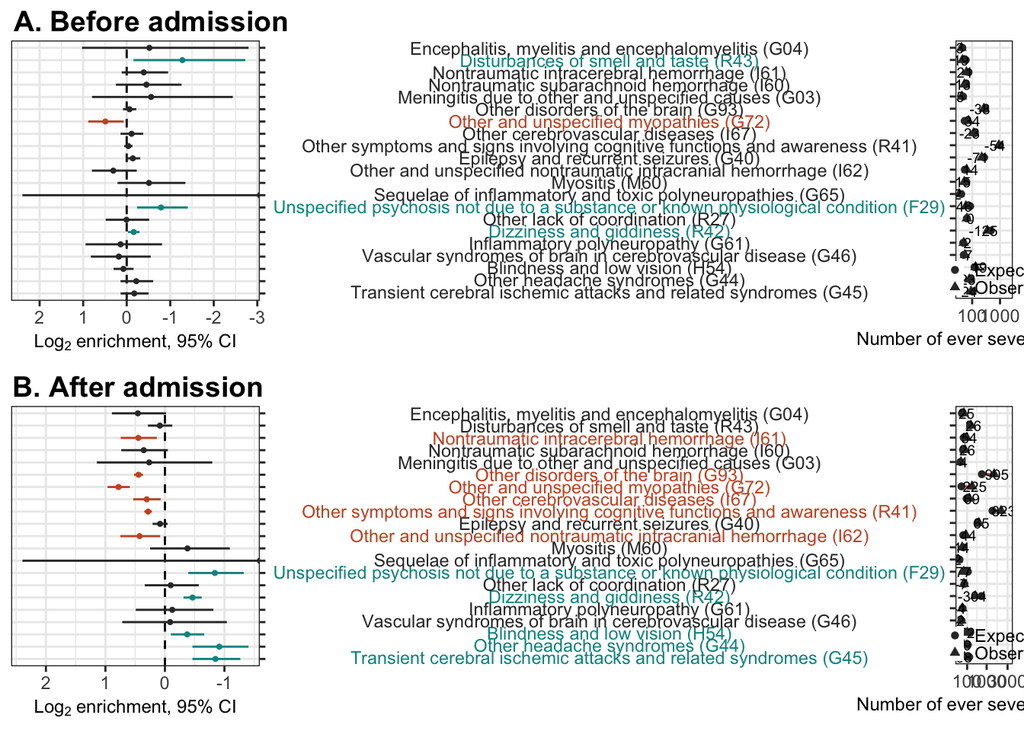

```r
enrichment_plot_before <- plot_enrich(
  plot_obs_exp_left %>% filter(time == 'Before admission'),
  plot_obs_exp_right %>% filter(time == 'Before admission') %>% slice(match(sorted_icds, full_icd)))
enrichment_plot_after <- plot_enrich(
  plot_obs_exp_left %>% filter(time == 'After admission'),
  plot_obs_exp_right %>% filter(time == 'After admission') %>% slice(match(sorted_icds, full_icd)))
enrichment_plot <- cowplot::plot_grid(
  enrichment_plot_before,
  enrichment_plot_after,
  ncol = 1, hjust = -0.05,
  labels = c('A. Before admission', 'B. After admission')
)
enrichment_plot
```

```r
ggsave('figs/icd_severe_before_after.png', enrichment_plot, width = 9.5, height = 7)
```

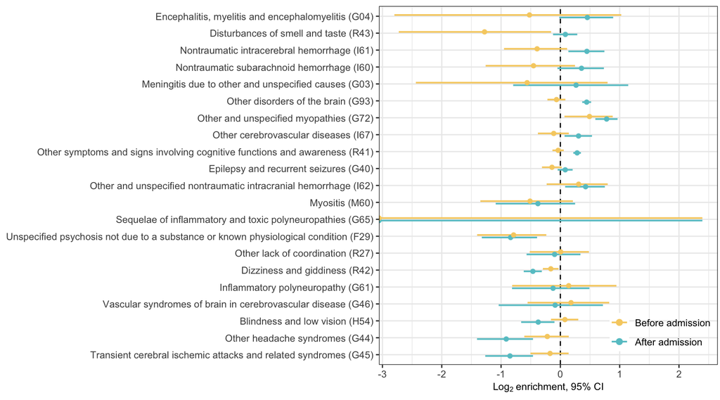

```r
plot_enrich_both <- plot_obs_exp %>%
  ggplot(aes(y = fct_relevel(full_icd, sorted_icds))) +
  geom_vline(aes(xintercept = 0), linetype = 2) +
  ggstance::geom_pointrangeh(
    aes(x = lestimate,
        xmin = llower,
        xmax = lupper,
        color = time),
    position = position_dodge(width = 0.3),
    stroke = 0.1, fatten = 3, size = 0.7
  ) +
  labs(y = NULL, x = bquote(Log[2] ~ 'enrichment, 95% CI')) +
  theme(
    legend.position = c(0.83, 0.1),
    legend.background = element_blank(),
    axis.title = element_text(size = 9),
    plot.margin = margin(5.5, 2, 5.5, 5.5, unit = 'pt')
  ) +
  scale_color_carto_d(palette = 4, guide = guide_legend(reverse = TRUE)) +
  NULL
plot_enrich_both
```

```r
ggsave('figs/icd_severe.png', plot_enrich_both, width = 9, height = 5)
```

ICDs:

```r
icd_10_to_9 <- read_delim('data/neurology10to9.txt', delim = '\t') %>%
  distinct()
```